# Lab_14T

36-600

Fall 2023

## Data: Part I

We’ll begin by importing the breast cancer dataset we’ve looked at previously:

```r
suppressMessages(library(tidyverse))
df        <- read.csv("http://www.stat.cmu.edu/~pfreeman/breastcancer.csv",stringsAsFactors=TRUE)
df        <- df[,c(1,16)]
names(df) <- c("x","Y")
```

We retain `Diagnosis` as our categorical predictor variable (now dubbed `x`) and `Worst.Smoothness` as the response variable (now dubbed `Y`).

## Question 1

Create a grouped boxplot and make a mental note as to whether or not it appears that the true means for each group are different.

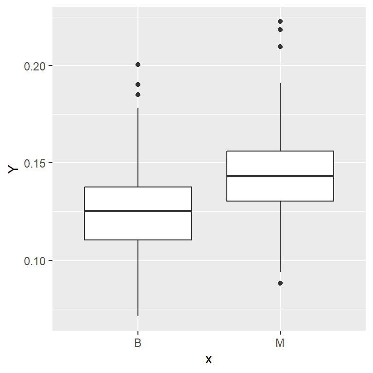

```r
set.seed(100)
suppressMessages(library(ggplot2))
ggplot(data = df, mapping = aes(x = x, y = Y))+geom_boxplot()
```

## Question 2

Now let’s determine if the assumptions underlying the use of the two-sample $t$ test hold…specifically, that the data within the individual groups are normally distributed with constant variance $\sigma^2$.

First, run a `shapiro.test()` on the data of groups `B` and `M`. If the $p$-value is less than $\alpha = 0.05$, we reject the null hypothesis that the data are normally distributed. (However, even if we reject the null hypothesis, we will still use these data below for illustrative purposes!)

Recall that in `dplyr` you can do the test as follows:

```
df %>% filter(.,x=="<INSERT CATEGORY NAME>") %>% select(.,Y) %>% pull(.) %>% shapiro.test(.)
```

The `pull()` function, which is new, coerces a column of numbers in a data frame to being “just” a vector…which we need to do because the Shapiro-Wilk test function doesn’t like data frames as inputs.

Go ahead and perform the test here, then state a conclusion.

```r
shapiro.test(df$Y)
```

```
##
##  Shapiro-Wilk normality test
##
## data:  df$Y
## W = 0.98862, p-value = 0.0002097
```

```r
df %>% filter(., x=="B")%>% select(.,Y) %>% pull(.)%>% shapiro.test(.)
```

```
##
##  Shapiro-Wilk normality test
##
## data:  .
## W = 0.99046, p-value = 0.02047
```

```r
df %>% filter(., x=="M")%>% select(.,Y) %>% pull(.)%>% shapiro.test(.)
```

```
##
##  Shapiro-Wilk normality test
##
## data:  .
## W = 0.98487, p-value = 0.02298
```

[output not shown]

Second, run the `leveneTest()` (from the `car` package). Here, you need not separate the data…you can simply input a model formula (`Y~x`) and specify `data=df`. If the $p$-value is less than $\alpha = 0.05$, we reject the null hypothesis that the variances are the same across groups. What do you conclude? (We should note a rule of thumb that you might see: two-sample $t$ tests and ANOVA are robust to heterogeneity of variance so long as the largest variance is no more than four times the smallest variance. So even if we reject the null here, we might very well still be able to pursue ANOVA.)

```r
suppressMessages(library(car))
leveneTest(Y~x, data = df)
```

```
## Levene's Test for Homogeneity of Variance (center = median)
##        Df F value Pr(>F)
## group   1   0.532 0.4661
##       567
```

```
From this it can be seen that we fail to reject the null hypothesis.
```

## Question 3

Now, run a two-sample $t$ test and make a conclusion about whether the response values for each group (`B` and `M`) have the same mean. Note that like for Levene’s test, the `t.test()` will allow you to input a model formula, so you don’t need to split up the data yourself. The null hypothesis, by the way, is that the difference in means is equal to zero.

```r
t.test(Y~x, data = df, alternative = "two.sided")
```

```
##
##  Welch Two Sample t-test
##
## data:  Y by x
## t = -10.82, df = 412.57, p-value < 2.2e-16
## alternative hypothesis: true difference in means between group B and group M is not equal to 0
## 95 percent confidence interval:
##  -0.02349864 -0.01627284
## sample estimates:
## mean in group B mean in group M
##       0.1249595       0.1448452
```

[output not shown]

## Data: Part II

We’ll continue by importing the hospital cost dataset we’ve looked at previously:

```r
df        <- read.csv("http://www.stat.cmu.edu/~pfreeman/hospital_cost.csv",stringsAsFactors=TRUE)
df        <- df[,c(5,1)]
names(df) <- c("x","Y")
df$x      <- factor(df$x)
w         <- which(df$Y==0)
df        <- df[-w,]
df$Y      <- log10(df$Y)
```

We retain `Drugs` as our categorical predictor variable (now dubbed `x`) and `Cost` as the response variable (now dubbed `Y`). The groups for `x` are “0”, “1”, and “2”. Note that we logarithmically transform `Y` after removing values of zero.

## Question 4

Repeat Q1 here: create a grouped boxplot and make a mental note as to whether or not it appears that the true means for each group are different.

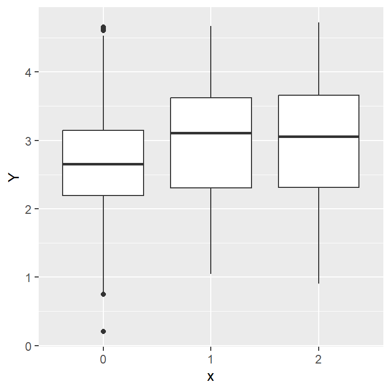

```r
set.seed(100)
ggplot(data = df, mapping = aes(x = x, y = Y))+geom_boxplot()
```

## Question 5

Repeat Q2 here: run three Shapiro-Wilk tests and one Levene’s test, and state which underlying assumptions of the ANOVA model hold here, and which do not. If Levene’s test indicates that the variances are truly unequal, compute the variances for each sample and see whether or not the rule-of-thumb given in Q2 can be applied here. (To compute variances, just use the same “codeflow” as you used for the Shapiro-Wilk test but put the `var()` function at the end.)

```r
df %>% filter(., x=="0")%>% select(.,Y) %>% pull(.)%>% shapiro.test(.)
```

```
##
##  Shapiro-Wilk normality test
##
## data:  .
## W = 0.99549, p-value = 0.07532
```

```r
df %>% filter(., x=="1")%>% select(.,Y) %>% pull(.)%>% shapiro.test(.)
```

```
##
##  Shapiro-Wilk normality test
##
## data:  .
## W = 0.9735, p-value = 0.06801
```

```r
df %>% filter(., x=="2")%>% select(.,Y) %>% pull(.)%>% shapiro.test(.)
```

```
##
##  Shapiro-Wilk normality test
##
## data:  .
## W = 0.9835, p-value = 0.3197
```

```r
leveneTest(Y~x, data = df)
```

```
## Levene's Test for Homogeneity of Variance (center = median)
##        Df F value   Pr(>F)
## group   2   5.462 0.004409 **
##       782
## ---
## Signif. codes:  0 '***' 0.001 '**' 0.01 '*' 0.05 '.' 0.1 ' ' 1
```

```r
df %>% filter(., x=="0")%>% select(.,Y) %>% pull(.)%>% var(.)
```

```
## [1] 0.6008959
```

```r
df %>% filter(., x=="1")%>% select(.,Y) %>% pull(.)%>% var(.)
```

```
## [1] 0.7996686
```

```r
df %>% filter(., x=="2")%>% select(.,Y) %>% pull(.)%>% var(.)
```

```
## [1] 0.7625903
```

```
From this it can be seen that the null hypothesis has failed to be rejected because of the fact that all values of p is greater than 0.05. After performing the levene test it can be seen that we can reject the null hypothesis because of the fact that the value of p is less than 0.05.
```

## Question 6

Show the summary output from regressing the variable `Y` upon `x`. What is the estimated mean response for each group?

```r
lm.out<-lm(Y~x, df)
summary(lm.out)
```

```
##
## Call:
## lm(formula = Y ~ x, data = df)
##
## Residuals:
##      Min       1Q   Median       3Q      Max
## -2.46244 -0.52889 -0.01008  0.52884  1.99096
##
## Coefficients:
##             Estimate Std. Error t value Pr(>|t|)
## (Intercept)  2.66656    0.03247  82.111  < 2e-16 ***
## x1           0.30586    0.09133   3.349  0.00085 ***
## x2           0.36439    0.09088   4.010 6.66e-05 ***
## ---
## Signif. codes:  0 '***' 0.001 '**' 0.01 '*' 0.05 '.' 0.1 ' ' 1
##
## Residual standard error: 0.8008 on 782 degrees of freedom
## Multiple R-squared:  0.0301, Adjusted R-squared:  0.02762
## F-statistic: 12.14 on 2 and 782 DF,  p-value: 6.45e-06
```

[output not shown]

## Question 7

Now pass the output from your call to linear regression into the `anova()` function. What is the hypothesis test statistic value and the $p$-value, and what conclusion do you draw?

```r
anova(lm.out)
```

```
## Analysis of Variance Table
##
## Response: Y
##            Df Sum Sq Mean Sq F value   Pr(>F)
## x           2  15.56  7.7817  12.136 6.45e-06 ***
## Residuals 782 501.42  0.6412
## ---
## Signif. codes:  0 '***' 0.001 '**' 0.01 '*' 0.05 '.' 0.1 ' ' 1
```

```
From performing anova it can be seen that we can reject the null hypothesis as the value of p is so much smaller than 0.05.
```

## Question 8

Here, pass the output from `aov(Y~x,data=df)` to the `TukeyHSD()` function and state a conclusion: which group or groups differ from the others? Which do we conclude have the same means?

```r
TukeyHSD(aov(Y~x, data = df))
```

```
##   Tukey multiple comparisons of means
##     95% family-wise confidence level
##
## Fit: aov(formula = Y ~ x, data = df)
##
## $x
##           diff         lwr       upr     p adj
## 1-0 0.30585828  0.09140064 0.5203159 0.0024467
## 2-0 0.36439321  0.15099065 0.5777958 0.0001967
## 2-1 0.05853493 -0.22413546 0.3412053 0.8778559
```

```
From this it can be seen that group 0 has a higher difference from group 1 and group 2 but group 1 and group 2 does not have significantly differenct means.
```